# p8105_hw6_sw3455

Shiying Wu

2024-12-02

```r
weather_df <- rnoaa::meteo_pull_monitors(
  c("USW00094728"),
  var = c("PRCP", "TMIN", "TMAX"),
  date_min = "2017-01-01",
  date_max = "2017-12-31"
) |>
  mutate(
    name = recode(id, USW00094728 = "CentralPark_NY"),
    tmin = tmin / 10,
    tmax = tmax / 10
  ) |>
  select(name, id, everything())
```

```
## using cached file: /Users/angel/Library/Caches/org.R-project.R/R/rnoaa/noaa_ghcnd/USW00094728.dly
```

```
## date created (size, mb): 2024-09-26 10:26:11.827766 (8.651)
```

```
## file min/max dates: 1869-01-01 / 2024-09-30
```

```r
bootstrap_analysis <- function(data, n_bootstrap = 5000) {
  results <- vector("list", n_bootstrap)

  for (i in 1:n_bootstrap) {
    sample_data <- data |> sample_frac(size = 1, replace = TRUE)
    model <- lm(tmax ~ tmin, data = sample_data)

    r_squared <- glance(model)$r.squared
    coefficients <- tidy(model)
    log_b0_b1 <- log(prod(coefficients$estimate))

    results[[i]] <- tibble(r_squared = r_squared, log_b0_b1 = log_b0_b1)
  }

  results_df <- bind_rows(results)
  return(results_df)
}

bootstrap_results <- bootstrap_analysis(weather_df)

str(bootstrap_results)
```

```
## tibble [5,000 × 2] (S3: tbl_df/tbl/data.frame)
##  $ r_squared: num [1:5000] 0.909 0.905 0.925 0.908 0.918 ...
##  $ log_b0_b1: num [1:5000] 2.06 2.02 1.99 2.04 2.07 ...
```

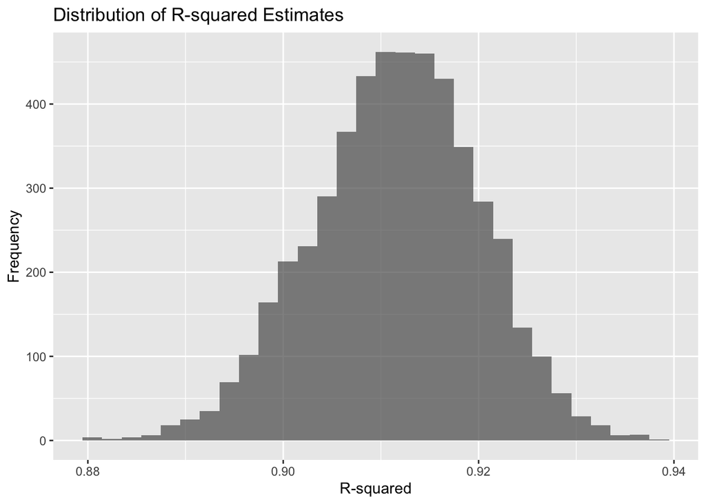

```r
ggplot(bootstrap_results, aes(x = r_squared)) +
  geom_histogram(bins = 30, alpha = 0.7) +
  labs(title = "Distribution of R-squared Estimates", x = "R-squared", y = "Frequency")
```

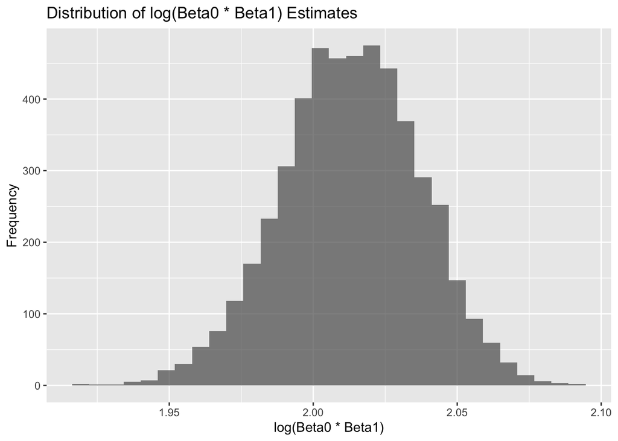

```r
ggplot(bootstrap_results, aes(x = log_b0_b1)) +
  geom_histogram(bins = 30, alpha = 0.7) +
  labs(title = "Distribution of log(Beta0 * Beta1) Estimates", x = "log(Beta0 * Beta1)", y = "Frequency")
```

```r
quantile(bootstrap_results$r_squared, probs = c(0.025, 0.975))
```

```
##      2.5%     97.5%
## 0.8945701 0.9271042
```

```r
quantile(bootstrap_results$log_b0_b1, probs = c(0.025, 0.975))
```

```
##     2.5%    97.5%
## 1.964166 2.058364
```

```r
homicide <- read_csv("data/homicide-data.csv", na = c(".", "NA", "", "Unknown"))
homicide <- homicide |>
  drop_na()|>
  mutate(city_state = paste(city, state, sep = ", "),
         solved = as.numeric(disposition == "Closed by arrest"),
         victim_age = as.numeric(victim_age)) |>
  filter(!city_state %in% c("Dallas, TX", "Phoenix, AZ", "Kansas City, MO", "Tulsa, AL"),
         victim_race %in% c("White", "Black")) |>
  mutate(victim_race = fct_relevel(victim_race, "White")) |>
  select(solved, city_state, victim_age, victim_race, victim_sex)

baltimore_model <-
  glm(solved ~ victim_age + victim_sex + victim_race, data = filter(homicide, city_state == "Baltimore, MD"), family = binomial())

save(baltimore_model, file = "baltimore_model.RData")

baltimore_model |>
  broom::tidy()|>
  filter(term == "victim_sexMale")|>
  mutate(
    or = exp(estimate),
    lower_ci = exp(estimate - 1.96 * std.error),
    upper_ci = exp(estimate + 1.96 * std.error)
  ) |>
  select(term, or, lower_ci, upper_ci, p.value) |>
  knitr::kable(digits = 3)
```

| term | or | lower_ci | upper_ci | p.value |
| --- | --- | --- | --- | --- |
| victim_sexMale | 0.426 | 0.325 | 0.558 | 0 |

The odds of solving a homicide in baltimore with a male victim are 0.426 times the odds of solving a homicide in baltimore with a female victim, holding all other variables constant. This indicates that homicides with female victims are more likely to be solved compared to those with male victims, as the odds ratio is less than 1 and statistically significant (p-value < 0.05).

```r
homicide_results <- homicide |>
  group_by(city_state) |>
  nest() |>
  mutate(
    model = map(data, ~ glm(solved ~ victim_sex + victim_age + victim_race, data = ., family = binomial())),
    tidied = map(model, tidy),
    glanced = map(model, glance)
  ) |>
  select(city_state, tidied, glanced) |>
  unnest(tidied) |>
  filter(term == "victim_sexMale") |>
  mutate(
    or = exp(estimate),
    lower_ci = exp(estimate - 1.96 * std.error),
    upper_ci = exp(estimate + 1.96 * std.error)
  ) |>
  select(city_state, or, lower_ci, upper_ci, p.value) |>
  arrange(or)
homicide_results |>
  knitr::kable(digits = 3)
```

| city_state | or | lower_ci | upper_ci | p.value |
| --- | --- | --- | --- | --- |
| San Bernardino, CA | 0.352 | 0.099 | 1.249 | 0.106 |
| San Diego, CA | 0.369 | 0.153 | 0.891 | 0.027 |
| Baton Rouge, LA | 0.381 | 0.209 | 0.695 | 0.002 |
| Omaha, NE | 0.382 | 0.203 | 0.721 | 0.003 |
| Cincinnati, OH | 0.400 | 0.236 | 0.677 | 0.001 |
| Chicago, IL | 0.410 | 0.336 | 0.501 | 0.000 |
| Long Beach, CA | 0.410 | 0.156 | 1.082 | 0.072 |
| Baltimore, MD | 0.426 | 0.325 | 0.558 | 0.000 |
| Pittsburgh, PA | 0.431 | 0.265 | 0.700 | 0.001 |
| Denver, CO | 0.479 | 0.236 | 0.971 | 0.041 |
| Philadelphia, PA | 0.490 | 0.373 | 0.645 | 0.000 |
| Louisville, KY | 0.491 | 0.305 | 0.790 | 0.003 |
| Buffalo, NY | 0.515 | 0.287 | 0.925 | 0.026 |
| Miami, FL | 0.515 | 0.304 | 0.872 | 0.013 |
| Columbus, OH | 0.546 | 0.387 | 0.770 | 0.001 |
| Oakland, CA | 0.563 | 0.365 | 0.868 | 0.009 |
| Detroit, MI | 0.582 | 0.462 | 0.734 | 0.000 |
| San Francisco, CA | 0.608 | 0.317 | 1.165 | 0.134 |
| New Orleans, LA | 0.641 | 0.453 | 0.906 | 0.012 |
| Boston, MA | 0.665 | 0.352 | 1.256 | 0.209 |
| Fort Worth, TX | 0.666 | 0.395 | 1.121 | 0.126 |
| San Antonio, TX | 0.672 | 0.369 | 1.222 | 0.193 |
| St. Louis, MO | 0.690 | 0.519 | 0.915 | 0.010 |
| Washington, DC | 0.691 | 0.469 | 1.018 | 0.062 |
| Houston, TX | 0.705 | 0.553 | 0.899 | 0.005 |
| Memphis, TN | 0.723 | 0.529 | 0.988 | 0.042 |
| Jacksonville, FL | 0.726 | 0.541 | 0.975 | 0.033 |
| Milwaukee, wI | 0.727 | 0.499 | 1.060 | 0.098 |
| Tampa, FL | 0.808 | 0.348 | 1.876 | 0.619 |
| Charlotte, NC | 0.845 | 0.530 | 1.347 | 0.479 |
| Las Vegas, NV | 0.847 | 0.614 | 1.168 | 0.311 |
| Savannah, GA | 0.867 | 0.422 | 1.780 | 0.697 |
| Birmingham, AL | 0.873 | 0.576 | 1.322 | 0.521 |
| Indianapolis, IN | 0.919 | 0.679 | 1.242 | 0.582 |
| Oklahoma City, OK | 0.974 | 0.624 | 1.520 | 0.908 |
| Tulsa, OK | 0.976 | 0.614 | 1.552 | 0.917 |
| Atlanta, GA | 1.003 | 0.686 | 1.468 | 0.987 |
| Richmond, VA | 1.006 | 0.498 | 2.033 | 0.987 |
| Durham, NC | 1.006 | 0.456 | 2.219 | 0.988 |
| Nashville, TN | 1.018 | 0.672 | 1.542 | 0.935 |
| Minneapolis, MN | 1.134 | 0.525 | 2.451 | 0.749 |
| Albuquerque, NM | 1.734 | 0.814 | 3.695 | 0.154 |
| Fresno, CA | 1.743 | 0.574 | 5.292 | 0.327 |